# Hypothesis Testing in R - Examples

**Pearson Correlation Test**

**When to use:** Use this test when you want to determine if there is a linear relationship between *two numerical variables*.

**How it works:** The test calculates the correlation coefficient (r) and tests if it is significantly different from zero.

**Pearson’s correlation coefficient** (r) measures the *strength* and *direction* of the linear relationship between two numerical variables.

**Range:** The value of r ranges from -1 to 1.

- *r = 1*: Perfect positive linear relationship.
- *r = −1:* Perfect negative linear relationship.
- *r = 0:* No linear relationship.

**Strength:** The closer the absolute value of r is to 1, the stronger the linear relationship.

- *|r| > 0.7:* Strong relationship
- *0.3 < |r| ≤ 0.7:* Moderate relationship
- *|r| ≤ 0.3:* Weak relationship

**Direction:** The sign of r indicates the direction of the relationship.

- Positive r: As one variable *increases*, the other variable also *increases.*
- Negative r: As one variable *increases*, the other variable *decreases*.

Let’s take a look at an example from the ‘mtcars’ dataset in R. This data was extracted from the 1974 Motor Trend US magazine, and comprises fuel consumption and 10 aspects of automobile design and performance for 32 automobiles (1973–74 models).

Let’s explore the relationship between the horsepower and miles per gallon of various cars.

**Null Hypothesis (H0):** There is *no correlation* between miles per gallon (mpg) and horsepower (hp) (correlation coefficient = 0).

**Alternative Hypothesis (H1):** There *is* a correlation between miles per gallon (mpg) and horsepower (hp) (correlation coefficient ≠ 0).

The following **scatterplot** shows this relationship visually:

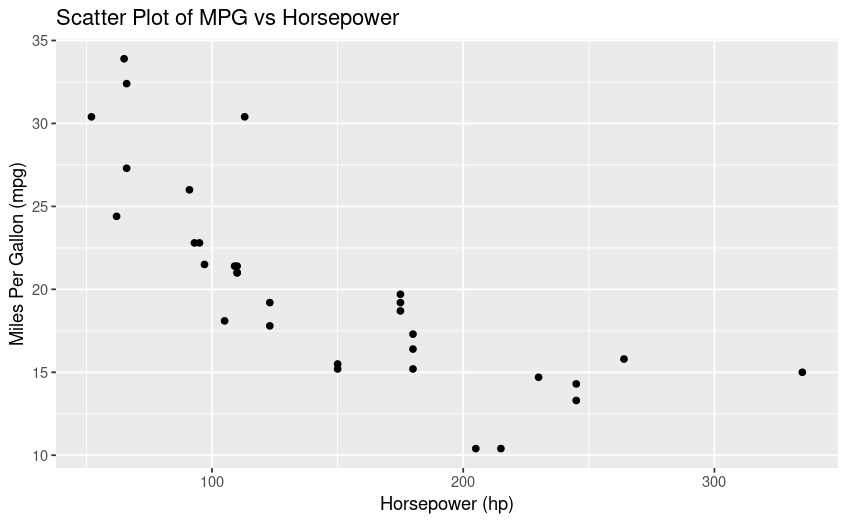

```r
data(mtcars)
library(ggplot2)

ggplot(mtcars, aes(x=hp, y=mpg)) +
  geom_point() +
  labs(title="Scatter Plot of MPG vs Horsepower",
       x="Horsepower (hp)",
       y="Miles Per Gallon (mpg)")
```

We can run the **Pearson correlation test** for these two variables using the **cor.test()** function in R:

```r
cor.test(mtcars$mpg, mtcars$hp)
```

```
    Pearson's product-moment correlation

data:  mtcars$mpg and mtcars$hp
t = -6.7424, df = 30, p-value = 1.788e-07
alternative hypothesis: true correlation is not equal to 0
95 percent confidence interval:
 -0.8852686 -0.5860994
sample estimates:
       cor
-0.7761684
```

Since the **p-value** was *below* 0.05 *(1.78e-07 is scientific notation for 0.000000178)*, we can **reject the null hypothesis** and say that there is a statistically significant correlation between miles per gallon and horsepower.

The “cor” value of **-0.776** gives the Pearson’s correlation coefficient between these two variables. This would be considered a **strong**, **negative relationship**, meaning that as the horsepower of a car increases, the miles per gallon of the car *decreases*.

**Chi-Squared Test**

**When to use:** Use this test to examine the association between *two categorical variables*.

**How it works:** The test compares the *observed* frequencies of categories to the *expected* frequencies if the variables were independent.

Let’s take a look at an example from the same dataset (mtcars). Take a look at the bar plot below showing the distribution of automatic and manual transmissions across cars with 4, 6, and 8 cylinders:

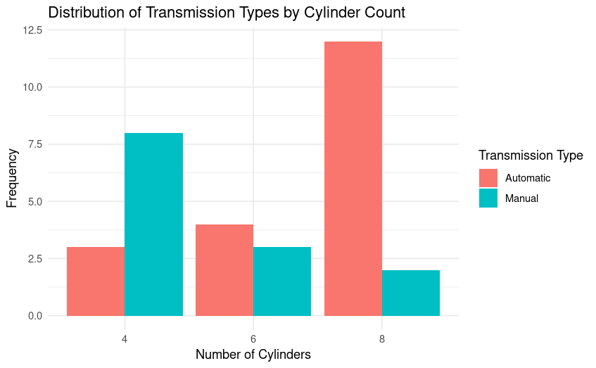

```r
ggplot(contingency_df, aes(x=Cylinders, y=Frequency, fill=Transmission)) +
  geom_bar(stat="identity", position="dodge") +
  labs(title="Distribution of Transmission Types by Cylinder Count",
       x="Number of Cylinders",
       y="Frequency",
       fill="Transmission Type") +
  theme_minimal()
```

Looking at this bar plot, there appears to be a relationship between the *transmission type* of the car and the *number of cylinders* the car has (the proportion of automatic cars seems to increase as the number of cylinders increase). Let’s perform a Chi-Squared Test to see if these two variables are independent:

**Null Hypothesis (H0):** The number of cylinders in a car *is independent* of the type of transmission. (In other words, the proportion of cars with different types of transmission (automatic or manual) *is the same* across different cylinder counts.)

**Alternative Hypothesis (H1):** The number of cylinders in a car *is not independent* of the type of transmission. (In other words, the proportion of cars with different types of transmission (automatic or manual) *varies* across different cylinder counts.)

We first need to create a **contingency table** to perform the test. This is a table that has three rows (the number of cylinders: 4, 6, or 8) and two columns (manual (1) and automatic (0). The values in each cell will be the count of how many cars fit into each of these subgroups *(i.e., the number of cars with 4 cylinders that are manual, the number of cars with 8 cylinders that are automatic, etc.).*

```r
contingency_table <- table(mtcars$cyl, mtcars$am)
print(contingency_table)
```

```
     0  1
  4  3  8
  6  4  3
  8 12  2
```

Now we can run the Chi-Squared Test using the **chisq.test()** function in R, which takes the contingency table we just made as the input.

```r
chi_squared_result <- chisq.test(contingency_table)
print(chi_squared_result)
```

```
    Pearson's Chi-squared test

data:  contingency_table
X-squared = 8.7407, df = 2, p-value = 0.01265
```

Well, if you take a look at the contingency table, some of the counts are very low (only 3 automatic cars have 4 cylinders!). For small samples where you have cells in your table that have expected counts that are *less than 5*, **Fisher’s Exact test** is a more appropriate statistical test to use (over Chi-Squared). Fortunately, we can easily perform that test instead using the **fisher.test()** function in R:

```r
fisher_result <- fisher.test(contingency_table)
print(fisher_result)
```

```
    Fisher's Exact Test for Count Data

data:  contingency_table
p-value = 0.009105
alternative hypothesis: two.sided
```

Since our p-value (0.009105) is below 0.5, we can **reject the null hypothesis** and accept the alternative hypothesis that the proportion of cars in the population with different types of transmission (automatic or manual) **does indeed vary** across different cylinder counts.

**Two-Sample t-Test**

**When to use:** Use this test to compare the means of a numerical variable between two different levels of a categorical variable. For example, you might use this test to determine if individuals who adopted a special diet (two categories: diet or no diet) had a reduced blood pressure compared to individuals who did not.

**How it works:** The test compares the means of the two groups and determines if they are statistically significantly different.

Let’s take a look at an example from the same dataset (mtcars). Take a look at the boxplots below comparing the mpgs for each type of transmission (the red diamond indicates the mean mpg):

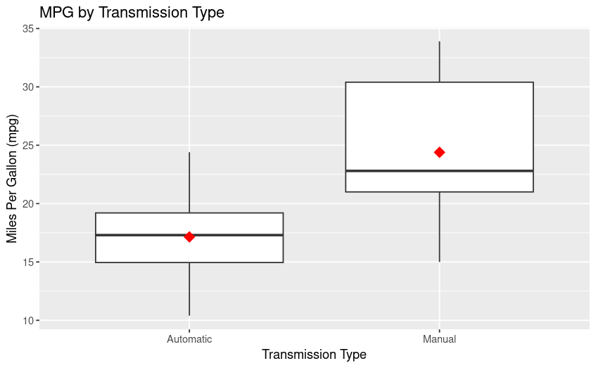

```r
ggplot(mtcars, aes(x=factor(am, labels=c("Automatic", "Manual")), y=mpg)) +
  geom_boxplot() +
  stat_summary(fun=mean, geom="point", shape=23, size=3, color="red", fill = "red") +
  labs(title="MPG by Transmission Type",
       x="Transmission Type",
       y="Miles Per Gallon (mpg)")
```

There appears to be a clear difference in the mean mpg between automatic and manual cars in our sample. Let’s perform a **Two-Sample t-Test** to see if this difference is statistically significant.

**Null Hypothesis (H0):** The mean mpg for automatic transmission cars is equal to the mean mpg for manual transmission cars.

**Alternative Hypothesis (H1):** The mean mpg for automatic transmission cars is not equal to the mean mpg for manual transmission cars.

We will use the **t.test** function in R to perform this test, which takes a *numerical variable* as the first input, then the *categorical variable* as the second input:

```r
t.test(mtcars$mpg ~ mtcars$am)
```

```
    Welch Two Sample t-test

data:  mtcars$mpg by mtcars$am
t = -3.7671, df = 18.332, p-value = 0.001374
alternative hypothesis: true difference in means between group 0 and group 1 is not equal to 0
95 percent confidence interval:
 -11.280194  -3.209684
sample estimates:
mean in group 0 mean in group 1
       17.14737        24.39231
```

Since our p-value (0.001374) is below 0.05, we can **reject the null hypothesis** and accept the alternative hypothesis that there is indeed **a statistically significant difference** between the average mpg for manual and automatic cars.

These are the main types of statistical inference tests you can use to determine statistically significant relationships in your data. Happy hypothesis testing!